# PCIT-CoS-Waitlist RCT Paper 1: ASQ Recoded

Nancy Briggs

2024-06-13

### ASQ

Output run on 2024-06-13

dataset: RTC_AQSdata_1_03_2024.xlsx

Variables: t1_aqs_score t2_aqs_score t3_aqs_score

#### Descriptives

| group | time | n | mean | sd | median | min | max |
| --- | --- | --- | --- | --- | --- | --- | --- |
| 1 | 1 | 27 | 0.127 | 0.442 | 0.243 | -0.630 | 0.772 |
| 1 | 2 | 16 | 0.338 | 0.347 | 0.358 | -0.437 | 0.845 |
| 1 | 3 | 12 | 0.308 | 0.144 | 0.262 | 0.056 | 0.603 |
| 2 | 1 | 26 | 0.044 | 0.397 | 0.062 | -0.568 | 0.663 |
| 2 | 2 | 13 | 0.069 | 0.311 | 0.030 | -0.394 | 0.562 |
| 2 | 3 | 4 | 0.352 | 0.175 | 0.327 | 0.188 | 0.567 |
| 3 | 1 | 25 | 0.153 | 0.421 | 0.252 | -0.610 | 0.682 |
| 3 | 2 | 18 | 0.201 | 0.373 | 0.332 | -0.516 | 0.685 |
| 3 | 3 | 0 | NaN | NA | NA | Inf | -Inf |

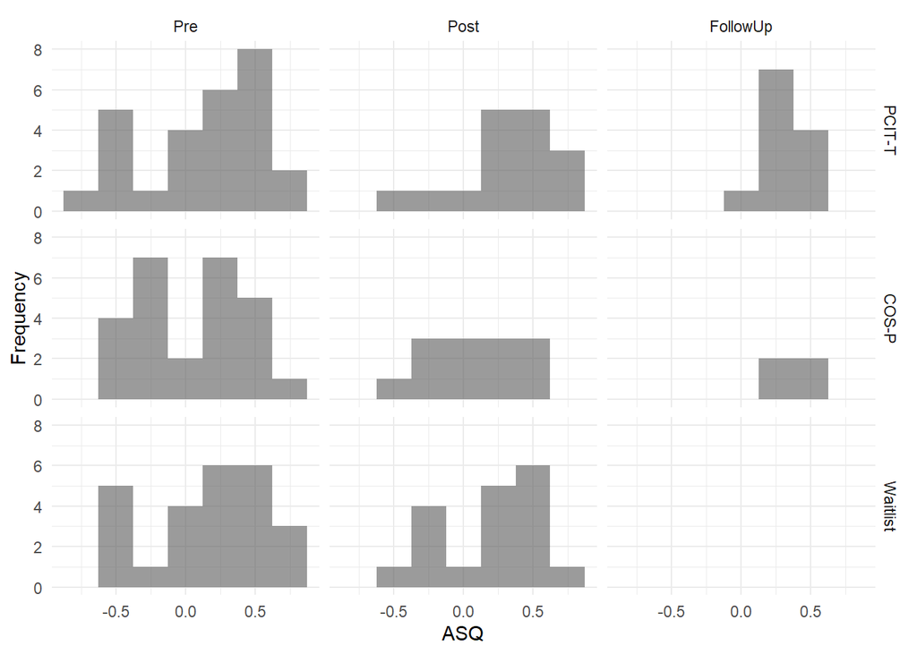

#### Model & Results

A linear mixed model with random effect for individual and fixed effects of group, time and the interaction was run. Estimated marginal means were obtained, and contrasts specified to test Hypothesis 1 and Hypothesis 2.

```
## fixed-effect model matrix is rank deficient so dropping 1 column / coefficient
```

```
## refitting model(s) with ML (instead of REML)
```

|  | Effect | npar | AIC | BIC | logLik | deviance | Chisq | Df | Pr(>Chisq) |
| --- | --- | --- | --- | --- | --- | --- | --- | --- | --- |
| result0 | Intercept | 3 | 128.254 | 137.100 | -61.127 | 122.254 | NA | NA | NA |
| result1 | Group | 5 | 128.932 | 143.676 | -59.466 | 118.932 | 3.322 | 2 | 0.190 |
| result2 | Time | 7 | 127.758 | 148.399 | -56.879 | 113.758 | 5.174 | 2 | 0.075 |
| result3 | Group*Time | 10 | 130.477 | 159.965 | -55.239 | 110.477 | 3.281 | 3 | 0.350 |

This is the ANOVA table for the model. p-values are likelihood ratio tests for adding the new term to the model just before. A p-value <0.05 indicates that adding that term results in better model fit. The most important p-value is the interaction p-value. Here, there is no evidence that the pattern of change over time is different among the groups (p=0.35).

```r
summary(result3)
```

```
## Linear mixed model fit by REML. t-tests use Satterthwaite's method [
## lmerModLmerTest]
## Formula: outcome ~ group * time + (1 | id)
##    Data: dat
##
## REML criterion at convergence: 134.1
##
## Scaled residuals:
##      Min       1Q   Median       3Q      Max
## -1.99392 -0.49046  0.08747  0.59528  1.73561
##
## Random effects:
##  Groups   Name        Variance Std.Dev.
##  id       (Intercept) 0.04509  0.2123
##  Residual             0.09809  0.3132
## Number of obs: 141, groups:  id, 79
##
## Fixed effects:
##               Estimate Std. Error        df t value Pr(>|t|)
## (Intercept)    0.12706    0.07282 120.06014   1.745   0.0836 .
## group2        -0.08284    0.10397 120.06014  -0.797   0.4272
## group3         0.03054    0.10492 120.93314   0.291   0.7715
## time2          0.21262    0.10258  72.94859   2.073   0.0417 *
## time3          0.18247    0.11428  76.55530   1.597   0.1145
## group2:time2  -0.21940    0.15175  76.09678  -1.446   0.1523
## group3:time2  -0.14617    0.14329  72.39701  -1.020   0.3111
## group2:time3   0.11162    0.21589  84.07423   0.517   0.6065
## ---
## Signif. codes:  0 '***' 0.001 '**' 0.01 '*' 0.05 '.' 0.1 ' ' 1
##
## Correlation of Fixed Effects:
##             (Intr) group2 group3 time2  time3  grp2:2 grp3:2
## group2      -0.700
## group3      -0.694  0.486
## time2       -0.486  0.341  0.338
## time3       -0.437  0.306  0.303  0.363
## group2:tim2  0.329 -0.469 -0.228 -0.676 -0.246
## group3:tim2  0.348 -0.244 -0.508 -0.716 -0.260  0.484
## group2:tim3  0.231 -0.330 -0.160 -0.192 -0.529  0.281  0.138
## fit warnings:
## fixed-effect model matrix is rank deficient so dropping 1 column / coefficient
```

#### Estimated Means & Change

Estimated means for each Treatment and Time are presented. In addition, within-group change between time points is presented with 95% CIs.

##### Group mean difference at each timepoint

Effect sizes all calculated by the pooled T1 SD of the outcome. Adjusted p-value from Bonferroni correction.

Group Differences at Each Time Point

| Group Difference | Time | Mean | SE | t | p | adj p | Lower CL | Upper CL | Effect Size | Lower CL | Upper CL |
| --- | --- | --- | --- | --- | --- | --- | --- | --- | --- | --- | --- |
| 1 - 2 | 1 | 0.083 | 0.104 | 0.797 | 0.706 | 1.000 | -0.164 | 0.330 | 0.197 | 0.032 | 0.631 |
| 1 - 3 | 1 | -0.031 | 0.105 | -0.291 | 0.954 | 1.000 | -0.280 | 0.218 | -0.073 | -0.639 | 0.440 |
| 2 - 3 | 1 | -0.113 | 0.106 | -1.070 | 0.534 | 0.860 | -0.365 | 0.138 | -0.270 | -0.757 | 0.185 |
| 1 - 2 | 2 | 0.302 | 0.139 | 2.177 | 0.079 | 0.094 | -0.027 | 0.631 | 0.718 | 0.165 | 1.393 |
| 1 - 3 | 2 | 0.116 | 0.128 | 0.902 | 0.640 | 1.000 | -0.188 | 0.420 | 0.275 | -0.018 | 0.730 |
| 2 - 3 | 2 | -0.187 | 0.136 | -1.376 | 0.357 | 0.514 | -0.508 | 0.135 | -0.444 | -0.824 | 0.123 |
| 1 - 2 | 3 | -0.029 | 0.209 | -0.138 | 0.990 | 1.000 | -0.524 | 0.466 | -0.068 | -0.963 | 0.827 |
| 1 - 3 | 3 | NA | NA | NA | NA | NA | NA | NA | NA | NA | NA |
| 2 - 3 | 3 | NA | NA | NA | NA | NA | NA | NA | NA | NA | NA |

* Effect size scaled by pooled T1 SD  
† ES 95% Bootstrapped Percentile CI limits  
‡ If you want a positive ES (and it is calculated as negative), be sure to switch the signs and positions of the lower and upper CIs.

##### Change within each group

Within-Group Change and Effect Sizes

| Change | Group | Mean | SE | t | p | adj p | Lower CL | Upper CL | Effect Size | Lower CL | Upper CL |
| --- | --- | --- | --- | --- | --- | --- | --- | --- | --- | --- | --- |
| 1 - 2 | 1 | -0.213 | 0.103 | -2.063 | 0.104 | 0.128 | -0.459 | 0.034 | -0.505 | -0.948 | -0.291 |
| 1 - 3 | 1 | -0.182 | 0.115 | -1.586 | 0.258 | 0.350 | -0.457 | 0.092 | -0.434 | -0.799 | -0.126 |
| 2 - 3 | 1 | 0.030 | 0.123 | 0.245 | 0.968 | 1.000 | -0.265 | 0.325 | 0.072 | -0.307 | 0.580 |
| 1 - 2 | 2 | 0.007 | 0.113 | 0.060 | 0.998 | 1.000 | -0.262 | 0.275 | 0.016 | -0.724 | 0.346 |
| 1 - 3 | 2 | -0.294 | 0.185 | -1.588 | 0.256 | 0.348 | -0.736 | 0.147 | -0.699 | -1.738 | -0.050 |
| 2 - 3 | 2 | -0.301 | 0.192 | -1.570 | 0.265 | 0.361 | -0.759 | 0.157 | -0.715 | -1.445 | 0.628 |
| 1 - 2 | 3 | -0.066 | 0.100 | -0.662 | 0.786 | 1.000 | -0.307 | 0.174 | -0.158 | -0.614 | 0.130 |
| 1 - 3 | 3 | NA | NA | NA | NA | NA | NA | NA | NA | NA | NA |
| 2 - 3 | 3 | NA | NA | NA | NA | NA | NA | NA | NA | NA | NA |

* Effect size scaled by pooled T1 SD  
† ES 95% Bootstrapped Percentile CI limits  
‡ If you want a positive ES (and it is calculated as negative), be sure to switch the signs and positions of the lower and upper CIs.

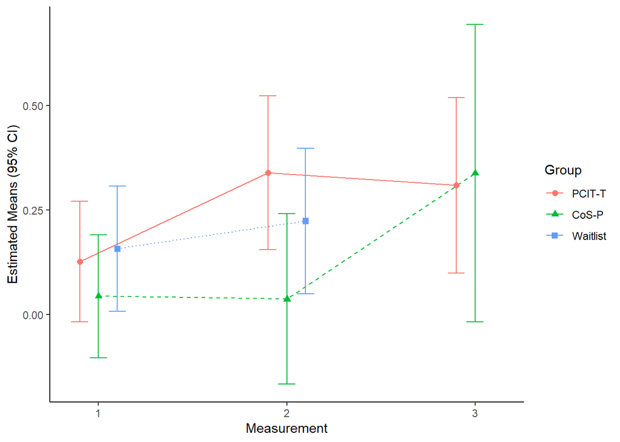

#### Hypothesis 1

We hypothesize that from baseline (‘T1’) to post-treatment/waitlist (‘T2’) there will be a gradient effect, whereby parent-child dyads who receive PCIT-T will show the greatest gains and parent-child dyads who receive no treatment will show the least gains. For the outcome, then, the null hypothesis is:

$H_0: \text {mean change}(\text{PCIT-T}) = \text {mean change}(\text{CoS-P}) = \text {mean change}(\text{Waitlist})$ $H_A: \text {mean change}(\text{PCIT-T}) > \text {mean change}(\text{CoS-P}) > \text {mean change}(\text{Waitlist})$

This is a joint hypothesis test.

First, confirming that the ordering of the means is as hypothesized:

```
## group = 1:
##  contrast estimate    SE   df t.ratio p.value
##  1 - 2    -0.21262 0.103 75.7  -2.063  0.1045
##  1 - 3    -0.18247 0.115 79.2  -1.586  0.2575
##  2 - 3     0.03015 0.123 68.9   0.245  0.9675
##
## group = 2:
##  contrast estimate    SE   df t.ratio p.value
##  1 - 2     0.00678 0.113 81.5   0.060  0.9980
##  1 - 3    -0.29409 0.185 89.6  -1.588  0.2561
##  2 - 3    -0.30087 0.192 79.2  -1.570  0.2647
##
## group = 3:
##  contrast estimate    SE   df t.ratio p.value
##  1 - 2    -0.06645 0.100 74.5  -0.662  0.7863
##  1 - 3      nonEst    NA   NA      NA      NA
##  2 - 3      nonEst    NA   NA      NA      NA
##
## Degrees-of-freedom method: kenward-roger
## P value adjustment: tukey method for comparing a family of 3 estimates
```

| contrast | group | t1t2change | quality | p.value |
| --- | --- | --- | --- | --- |
| 1 - 2 | 1 | 0.213 | increase t1 to t2 | 0.104 |
| 1 - 2 | 2 | -0.007 | decreased t1 to t2 | 0.998 |
| 1 - 2 | 3 | 0.066 | increase t1 to t2 | 0.786 |

Is the ordering of change satisfied?

Greatest to least change from t1 to t2: Order not satisfied

Note that I interpreted an increase in scores as being “better”. If a decrease in scores is “better” then these change values should be interpreted in that light.

```
##   (Intercept) group2 group3 time2 time3 group2:time2 group3:time2 group2:time3
## 1           0      0      0     0     0            1            0            0
## 2           0      0      0     0     0           -1            1            0
```

```
##
##   General Linear Hypotheses
##
## Linear Hypotheses:
##        Estimate
## 1 == 0 -0.21940
## 2 == 0  0.07323
##
## Global Test:
##       F DF1 DF2 Pr(>F)
## 1 1.112   2 131 0.3319
```

p= 0.332. We have no evidence that there is a difference in the change over from Baseline to Post amongst the groups.

#### Hypothesis 2

##### Change from T2-T3

There will be a gradient of size of change from T2 to T3 such that the change in the PCIT-T group > the change in the CoS-P group. This isn’t really a gradient; it’s just 1 hypothesis.

First, the change in PCITT and COSP from time 2 to time 3:

```
## group = 1:
##  time emmean     SE  df lower.CL upper.CL
##  1    0.1271 0.0728 121  -0.0171    0.271
##  2    0.3397 0.0931 133   0.1556    0.524
##  3    0.3095 0.1062 131   0.0995    0.520
##
## group = 2:
##  time emmean     SE  df lower.CL upper.CL
##  1    0.0442 0.0742 121  -0.1027    0.191
##  2    0.0374 0.1031 133  -0.1664    0.241
##  3    0.3383 0.1796 113  -0.0176    0.694
##
## group = 3:
##  time emmean     SE  df lower.CL upper.CL
##  1    0.1576 0.0756 123   0.0080    0.307
##  2    0.2241 0.0882 131   0.0495    0.399
##  3    nonEst     NA  NA       NA       NA
##
## Degrees-of-freedom method: kenward-roger
## Confidence level used: 0.95
```

```
## group = 1:
##  contrast estimate    SE   df lower.CL upper.CL
##  1 - 2    -0.21262 0.103 75.7   -0.459   0.0338
##  1 - 3    -0.18247 0.115 79.2   -0.457   0.0923
##  2 - 3     0.03015 0.123 68.9   -0.265   0.3252
##
## group = 2:
##  contrast estimate    SE   df lower.CL upper.CL
##  1 - 2     0.00678 0.113 81.5   -0.262   0.2754
##  1 - 3    -0.29409 0.185 89.6   -0.736   0.1473
##  2 - 3    -0.30087 0.192 79.2   -0.759   0.1569
##
## group = 3:
##  contrast estimate    SE   df lower.CL upper.CL
##  1 - 2    -0.06645 0.100 74.5   -0.307   0.1737
##  1 - 3      nonEst    NA   NA       NA       NA
##  2 - 3      nonEst    NA   NA       NA       NA
##
## Degrees-of-freedom method: kenward-roger
## Confidence level used: 0.95
## Conf-level adjustment: tukey method for comparing a family of 3 estimates
```

```r
## Specify contrast matrices
# Hyp1 is 1 df test
# could use alternative="less" ir alternative="greater" in glht
hyp2   <- matrix(c(0, 0,0, 0,0, -1,0,1 ),1)
hyp2F <- glht(result3, linfct = hyp2)
summary(hyp2F)
```

```
##
##   Simultaneous Tests for General Linear Hypotheses
##
## Fit: lmer(formula = outcome ~ group * time + (1 | id), data = dat)
##
## Linear Hypotheses:
##        Estimate Std. Error z value Pr(>|z|)
## 1 == 0   0.3310     0.2263   1.463    0.143
## (Adjusted p values reported -- single-step method)
```

```r
s<-summary(hyp2F, test = Ftest())
#also see this webpage for more on contrasts https://rcompanion.org/rcompanion/h_01.html



## Extract pvaue for evidence / no evidence
evidence = ifelse(s$test$pvalue<0.05, "evidence", "no evidence")
```

Change in G1 from T2 to T3: 0.03

Change in G2 from T2 to T3: -0.301

##### Change from T1-T3

```
##
##   General Linear Hypotheses
##
## Linear Hypotheses:
##        Estimate
## 1 == 0   0.1116
##
## Global Test:
##        F DF1 DF2 Pr(>F)
## 1 0.2673   1 131  0.606
```

Change in G1 from T1 to T3: -0.182

Change in G2 from T1 to T3: -0.294

p=0.606. We have no evidence that the change from T1 to T3 is different for G1 and G2

#### Residuals

Assumptions of the model are met.

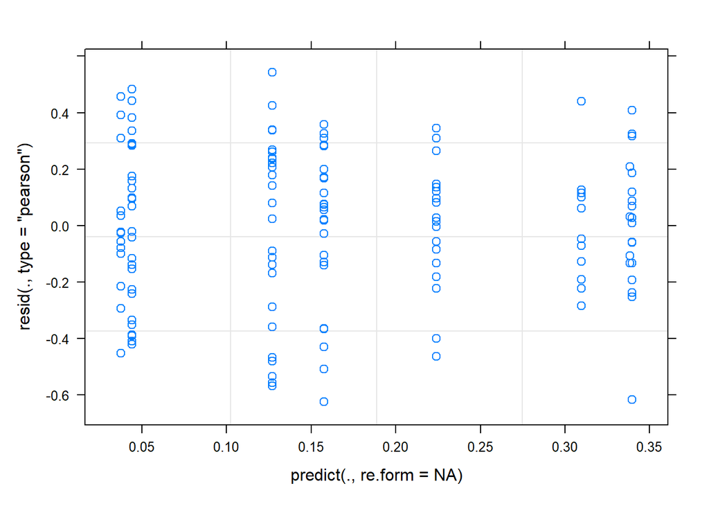

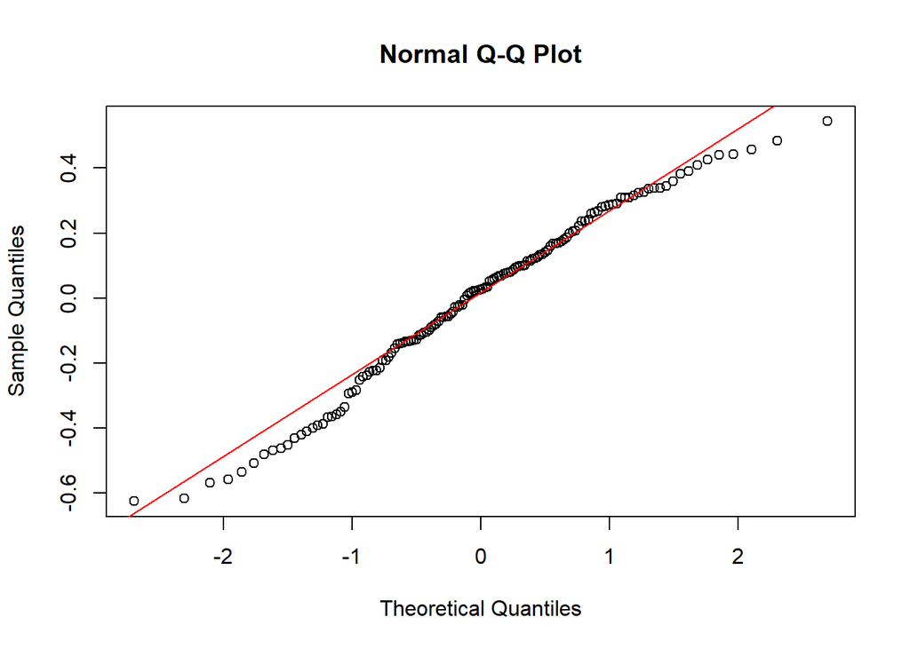

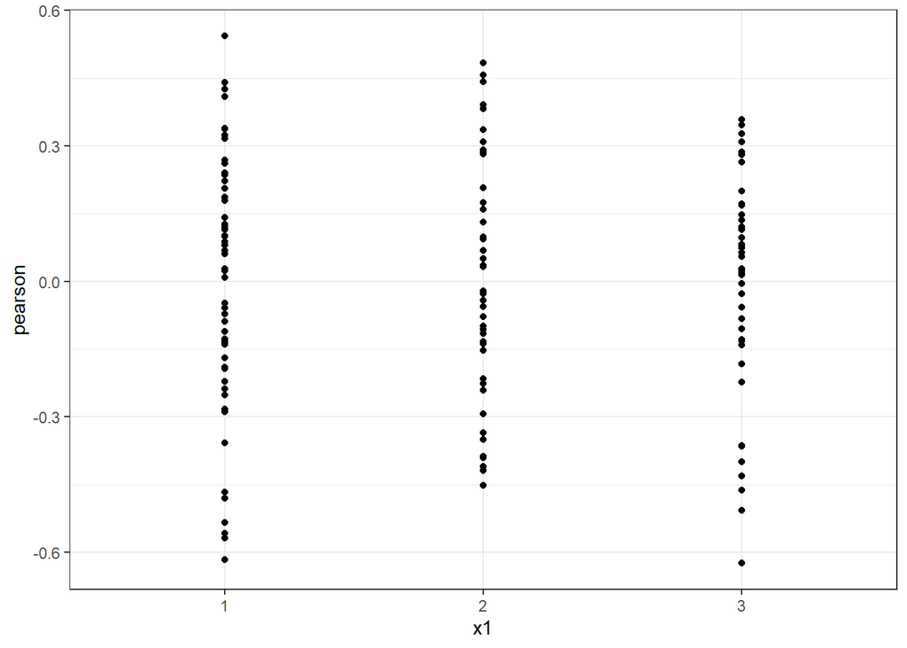

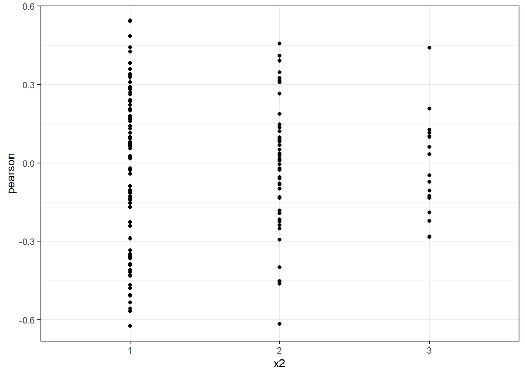

```r
rm(list = ls())
```